# Improving people’s training

Tomas Fuenzalida

29 de mayo de 2020

## Objetive

The objective of this project is to put into practice the knowledge acquired in the Machine Learning course, part of the Data Science specialization in coursera taught by John Hopkins University. For this, the data delivered by different devices will be used when performing a physical exercise on different people, which will be rated according to the technique used. With these observations, a classification model will be calibrated that allows estimating 20 observations that have not been classified.

## Background

Using devices such as Jawbone Up, Nike FuelBand, and Fitbit it is now possible to collect a large amount of data about personal activity relatively inexpensively. These type of devices are part of the quantified self movement – a group of enthusiasts who take measurements about themselves regularly to improve their health, to find patterns in their behavior, or because they are tech geeks. One thing that people regularly do is quantify how much of a particular activity they do, but they rarely quantify how well they do it. In this project, your goal will be to use data from accelerometers on the belt, forearm, arm, and dumbell of 6 participants. They were asked to perform barbell lifts correctly and incorrectly in 5 different ways. More information is available from the website here: http://web.archive.org/web/20161224072740/http:/groupware.les.inf.puc-rio.br/har (see the section on the Weight Lifting Exercise Dataset).

## Data

The training data for this project are available here:

https://d396qusza40orc.cloudfront.net/predmachlearn/pml-training.csv

The test data are available here:

https://d396qusza40orc.cloudfront.net/predmachlearn/pml-testing.csv

The data for this project come from this source: http://web.archive.org/web/20161224072740/http:/groupware.les.inf.puc-rio.br/har. If you use the document you create for this class for any purpose please cite them as they have been very generous in allowing their data to be used for this kind of assignment.

## Download, Pre-process and analisis Data

```r
library(dplyr)
library(ggplot2)
library(caret)
```

Download the training dataset

```r
data <- read.table("pml-training.csv", header = TRUE, sep = ",", na.strings = c("","NA"))
```

I remove the variables that do not generate a contribution to a future model such as time

```r
data <- data[,-c(1,3,4,5,6,7)]
```

I remove all the columns that have NA

```r
data <- data[ , colSums(is.na(data)) == 0]
```

To see possible relationships between the form of the exercise and the different research participants, we made a plot of the number of exercises qualified by each person

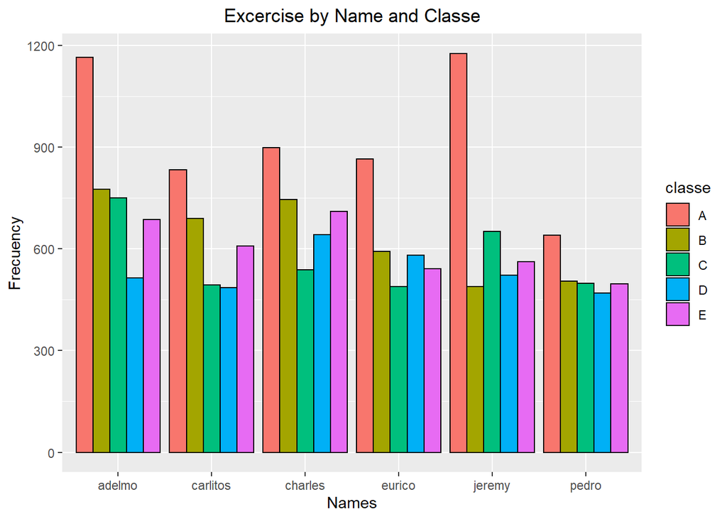

```r
g <- ggplot(data, aes(x = user_name, fill = classe))
g <- g + geom_bar(position = "dodge", col = "black");
g <- g + labs(title = "Excercise by Name and Classe", x = "Names", y = "Frecuency");
g <- g+ theme(plot.title = element_text(hjust = 0.5)); g
```

```r
data <- data[,-c(1)]
```

We create the data partition between my training data and my testing data.

```r
inTrain <- createDataPartition(y = data$classe, p = 0.7, list = FALSE)
training <- data[inTrain,]
testing <- data[-inTrain,]
```

In order to better select the variables that can best explain the type of exercise being done, we seek to verify that all of these have minimal variability so that they deliver value to the model.

```r
nearZeroVar(training,saveMetrics = TRUE)
```

```
##                      freqRatio percentUnique zeroVar   nzv
## roll_belt             1.116129    8.02213001   FALSE FALSE
## pitch_belt            1.098485   12.30982019   FALSE FALSE
## yaw_belt              1.067416   13.11057727   FALSE FALSE
## total_accel_belt      1.055864    0.20382907   FALSE FALSE
## gyros_belt_x          1.067021    0.93906967   FALSE FALSE
## gyros_belt_y          1.120507    0.50229308   FALSE FALSE
## gyros_belt_z          1.071960    1.17201718   FALSE FALSE
## accel_belt_x          1.086792    1.16473757   FALSE FALSE
## accel_belt_y          1.089804    1.00458615   FALSE FALSE
## accel_belt_z          1.041074    2.11108685   FALSE FALSE
## magnet_belt_x         1.129555    2.21300138   FALSE FALSE
## magnet_belt_y         1.096197    2.10380724   FALSE FALSE
## magnet_belt_z         1.027273    3.15207105   FALSE FALSE
## roll_arm             51.866667   17.57297809   FALSE FALSE
## pitch_arm            70.757576   20.47026279   FALSE FALSE
## yaw_arm              31.540541   19.23272913   FALSE FALSE
## total_accel_arm       1.052716    0.47317464   FALSE FALSE
## gyros_arm_x           1.061453    4.58615418   FALSE FALSE
## gyros_arm_y           1.408971    2.64977797   FALSE FALSE
## gyros_arm_z           1.117962    1.68158987   FALSE FALSE
## accel_arm_x           1.016000    5.55434229   FALSE FALSE
## accel_arm_y           1.056604    3.84363398   FALSE FALSE
## accel_arm_z           1.088889    5.60529956   FALSE FALSE
## magnet_arm_x          1.166667    9.56540729   FALSE FALSE
## magnet_arm_y          1.105263    6.20950717   FALSE FALSE
## magnet_arm_z          1.024691    9.09951227   FALSE FALSE
## roll_dumbbell         1.136364   86.69287326   FALSE FALSE
## pitch_dumbbell        2.180000   84.45803305   FALSE FALSE
## yaw_dumbbell          1.136364   85.99403072   FALSE FALSE
## total_accel_dumbbell  1.034411    0.29846400   FALSE FALSE
## gyros_dumbbell_x      1.018605    1.70342870   FALSE FALSE
## gyros_dumbbell_y      1.310000    1.93637621   FALSE FALSE
## gyros_dumbbell_z      1.040189    1.40496469   FALSE FALSE
## accel_dumbbell_x      1.004292    2.97736041   FALSE FALSE
## accel_dumbbell_y      1.027322    3.31222246   FALSE FALSE
## accel_dumbbell_z      1.108434    2.90456432   FALSE FALSE
## magnet_dumbbell_x     1.045455    7.78190289   FALSE FALSE
## magnet_dumbbell_y     1.215385    6.00567810   FALSE FALSE
## magnet_dumbbell_z     1.059259    4.81910170   FALSE FALSE
## roll_forearm         11.777778   13.73662372   FALSE FALSE
## pitch_forearm        62.613636   19.01434083   FALSE FALSE
## yaw_forearm          15.471910   12.73931717   FALSE FALSE
## total_accel_forearm   1.170388    0.48773386   FALSE FALSE
## gyros_forearm_x       1.109589    2.03829075   FALSE FALSE
## gyros_forearm_y       1.037037    5.24859868   FALSE FALSE
## gyros_forearm_z       1.124629    2.05284997   FALSE FALSE
## accel_forearm_x       1.213115    5.67809565   FALSE FALSE
## accel_forearm_y       1.142857    7.16313606   FALSE FALSE
## accel_forearm_z       1.057143    4.02562423   FALSE FALSE
## magnet_forearm_x      1.142857   10.62095072   FALSE FALSE
## magnet_forearm_y      1.131148   13.34352479   FALSE FALSE
## magnet_forearm_z      1.097561   11.72017180   FALSE FALSE
## classe                1.469526    0.03639805   FALSE FALSE
```

As can be seen, there are no variables with variability close to 0, so we use all the variables and start pre-processing the data with the center and scaling method.

```r
preobj <- preProcess(training, method = c("center","scale"))
training <- predict(preobj, training)
```

## Training the Model

Since the problem corresponds to one of classification, the “random forest” technique was used to tuiolize with 3 cross validations to reduce the computational load

```r
mod1 <- train(classe ~ ., data = training, method = "rf", trControl = trainControl(method = "cv", number = 3))
```

```r
pred1 <- predict(mod1,training)
confusionMatrix(pred1, training$classe)
```

```
## Confusion Matrix and Statistics
##
##           Reference
## Prediction    A    B    C    D    E
##          A 3906    3    0    0    0
##          B    0 2655    4    0    0
##          C    0    0 2391   14    0
##          D    0    0    1 2238    0
##          E    0    0    0    0 2525
##
## Overall Statistics
##
##                Accuracy : 0.9984
##                  95% CI : (0.9976, 0.999)
##     No Information Rate : 0.2843
##     P-Value [Acc > NIR] : < 2.2e-16
##
##                   Kappa : 0.998
##
##  Mcnemar's Test P-Value : NA
##
## Statistics by Class:
##
##                      Class: A Class: B Class: C Class: D Class: E
## Sensitivity            1.0000   0.9989   0.9979   0.9938   1.0000
## Specificity            0.9997   0.9996   0.9988   0.9999   1.0000
## Pos Pred Value         0.9992   0.9985   0.9942   0.9996   1.0000
## Neg Pred Value         1.0000   0.9997   0.9996   0.9988   1.0000
## Prevalence             0.2843   0.1935   0.1744   0.1639   0.1838
## Detection Rate         0.2843   0.1933   0.1741   0.1629   0.1838
## Detection Prevalence   0.2846   0.1936   0.1751   0.1630   0.1838
## Balanced Accuracy      0.9998   0.9993   0.9983   0.9968   1.0000
```

After the model training, we perform the same sequence to the test data from the pre-process to the prediction.

```r
preobj_testing <- preProcess(testing, method = c("center","scale"))
testing <- predict(preobj, testing)
pred2 <- predict(mod1,testing)
confusionMatrix(pred2, testing$classe)
```

```
## Confusion Matrix and Statistics
##
##           Reference
## Prediction    A    B    C    D    E
##          A 1674    2    0    0    0
##          B    0 1137    0    0    0
##          C    0    0 1024    3    0
##          D    0    0    2  961    0
##          E    0    0    0    0 1082
##
## Overall Statistics
##
##                Accuracy : 0.9988
##                  95% CI : (0.9976, 0.9995)
##     No Information Rate : 0.2845
##     P-Value [Acc > NIR] : < 2.2e-16
##
##                   Kappa : 0.9985
##
##  Mcnemar's Test P-Value : NA
##
## Statistics by Class:
##
##                      Class: A Class: B Class: C Class: D Class: E
## Sensitivity            1.0000   0.9982   0.9981   0.9969   1.0000
## Specificity            0.9995   1.0000   0.9994   0.9996   1.0000
## Pos Pred Value         0.9988   1.0000   0.9971   0.9979   1.0000
## Neg Pred Value         1.0000   0.9996   0.9996   0.9994   1.0000
## Prevalence             0.2845   0.1935   0.1743   0.1638   0.1839
## Detection Rate         0.2845   0.1932   0.1740   0.1633   0.1839
## Detection Prevalence   0.2848   0.1932   0.1745   0.1636   0.1839
## Balanced Accuracy      0.9998   0.9991   0.9987   0.9982   1.0000
```

## Select Model

```r
mod1$finalModel
```

```
##
## Call:
##  randomForest(x = x, y = y, mtry = param$mtry)
##                Type of random forest: classification
##                      Number of trees: 500
## No. of variables tried at each split: 2
##
##         OOB estimate of  error rate: 0.69%
## Confusion matrix:
##      A    B    C    D    E  class.error
## A 3904    2    0    0    0 0.0005120328
## B   16 2636    6    0    0 0.0082768999
## C    0   20 2372    4    0 0.0100166945
## D    0    0   39 2211    2 0.0182060391
## E    0    0    0    6 2519 0.0023762376
```

We select this model as it has less than a 1% error which is strong enough to be an almost perfect model

# Predict data not found

The final test data is finally opened and used to predict the missing data

```r
data_test <- read.table("pml-testing.csv", header = TRUE, sep = ",", na.strings = c("","NA"))
preobj_test <- preProcess(data_test, method = c("center","scale"))
data_test <- predict(preobj, data_test)
pred_test <- predict(mod1,data_test); pred_test
```

```
##  [1] B A B A A E D B A A B C B A E E A B B B
## Levels: A B C D E
```